# Лабораторная работа №16

Администрирование локальных сетей

Ибрахим Мохсейн Алькамаль

1032225432@rudn.ru

Российский университет дружбы народов

2026-05-30

# Информация

## Докладчик

- Ибрахим Мохсейн Алькамаль
- Российский университет дружбы народов
- [GitHub](https://github.com/Ebrahimalkamal2027)

# Цель работы

- Получение навыков настройки VPN-туннеля через незащищённое Интернетсоединение.

# Выполнение лабораторной работы

## Создание площадки Университета г. Пиза

- Создана дополнительная площадка Университета г. Пиза
- Добавлены маршрутизатор, коммутатор, ПК и подключение к Интернету

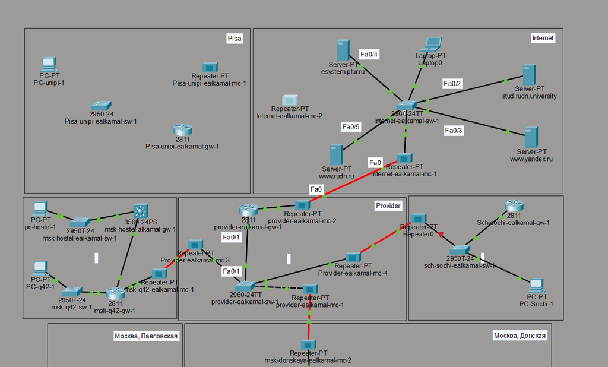

Рисунок 1: Топология сети Университета г. Пиза в логической рабочей области

## Создание физической структуры

- Создан город Pisa
- Создан объект University of Pisa

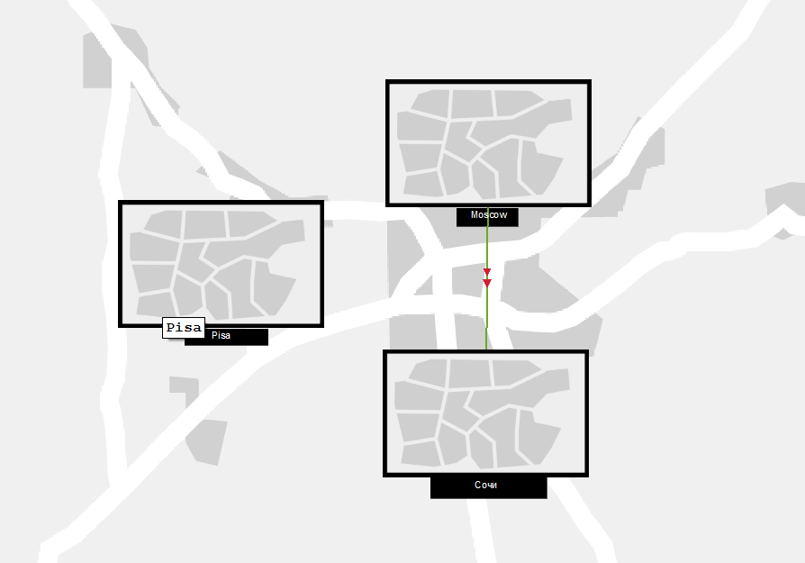

Рисунок 2: Создание города Pisa в физической рабочей области

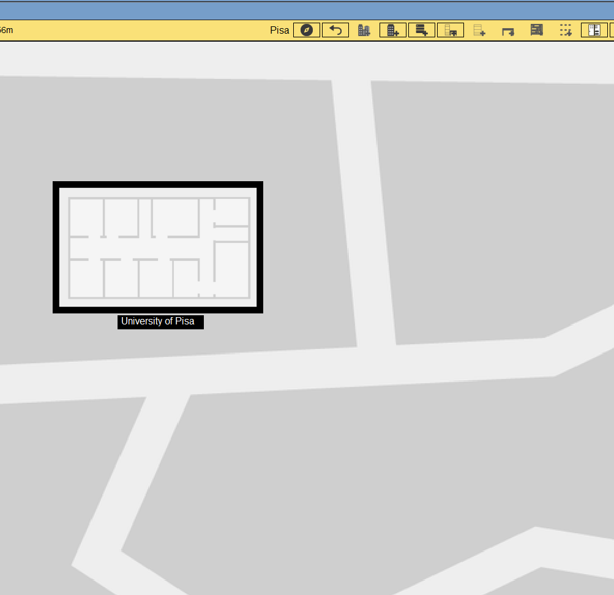

Рисунок 3: Создание здания University of Pisa

## Размещение оборудования

- Оборудование сети размещено внутри здания University of Pisa

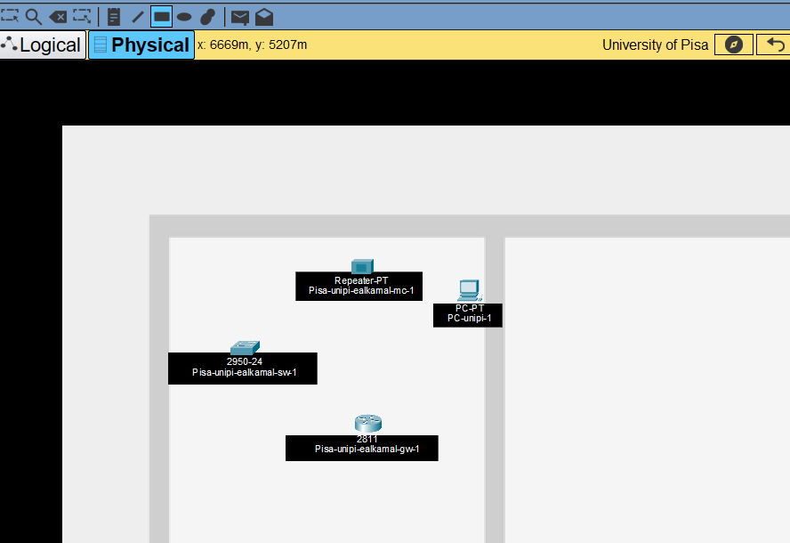

Рисунок 4: Размещение оборудования сети Университета г. Пиза в здании

## Первоначальная настройка маршрутизатора Pisa

- Настроены консольные и VTY-линии
- Создан пользователь admin
- Настроено доменное имя `unipi.edu`
- Сгенерированы RSA-ключи
- Включён доступ по SSH

[figure not shown]

## Первоначальная настройка коммутатора Pisa

- Настроены консольные и VTY-линии
- Создан пользователь admin
- Настроено доменное имя `unipi.edu`
- Сгенерированы RSA-ключи
- Настроен доступ по SSH

[figure not shown]

## Настройка интерфейсов маршрутизатора Pisa

- Создан подинтерфейс `FastEthernet0/0.401`
- Назначен адрес `10.131.0.1/24`
- Настроен интерфейс `FastEthernet0/1` с адресом `192.0.2.20/24`
- Добавлен маршрут по умолчанию через `192.0.2.1`

[figure not shown]

## Настройка коммутатора Pisa

- Настроен транковый порт `FastEthernet0/24`
- Создана VLAN 401 `unipi-main`
- Порт `FastEthernet0/1` назначен в VLAN 401

[figure not shown]

## Настройка GRE-туннеля на маршрутизаторе Донская

- Создан интерфейс `Tunnel0`
- Назначен адрес `10.128.255.253/30`
- Указан источник туннеля `FastEthernet0/1.4`
- Указан адрес назначения `192.0.2.20`
- Создан интерфейс `Loopback0`
- Добавлен статический маршрут

[figure not shown]

## Настройка GRE-туннеля и OSPF на маршрутизаторе Pisa

- Создан интерфейс `Tunnel0`
- Назначен адрес `10.128.255.254/30`
- Создан интерфейс `Loopback0` с адресом `10.128.254.5/32`
- Добавлен статический маршрут
- Настроен процесс OSPF
- Установлен Router ID `10.128.254.5`

[figure not shown]

## Итоговая схема сети

- Сформирована итоговая топология сети
- Добавлена площадка Университета г. Пиза
- Настроено подключение к Интернету
- Настроен VPN-туннель между Москвой и Пизой

[figure not shown]

# Выводы

- Выполнена настройка площадки Университета г. Пиза
- Настроено сетевое оборудование
- Создан GRE-туннель между сетью Университета г. Пиза и сетью «Донская»
- Выполнена настройка маршрутизации OSPF